# frETH Simulations

CharlieDAO

12/30/2021

## Intro

Deep Freeze provides intrinsic yield for long term holdings of blockchain native assets (e.g., ETH on Ethereum). This report details a simple simulation of random vaults, deposits, time-periods of lock, and patience profiles of vault owners to understand potential reactions to the Deep Freeze tokenomics model as described in Tokenized Patience - the Deep Freeze Intrinsic Yield white paper. Please see this paper for more on the theory of intrinsic yield and tokenized patience.

## Plan

There are `n` vaults each owned by a single individual for simplicity’s sake. Each vault has:

```
* a random amount of ETH deposited,
* a random amount of time (in years) that deposit is locked
* the resulting amount of frozen ETh "frETH" minted via that lock
* the amount of time that must pass (in years) for a vault to be "breakeven" (67% of lock time)
* Cost breakdrowns (in frETH) for withdrawing from the freezer at 5 points in time:
    - Immediate withdrawal (i.e. mint amount + 20% frETH penalty)
    - Halfway withdrawal (mint amount + 10% frETH penalty)
    - Breakeven (mint amount, no frETH penalty)
    - 3/4ths of the way through lock time (50% of mint amount, i.e. a frETH profit)
    - Completed lock time (can withdraw without returning any mint amount, i.e. 100% frETH profit)
```

Each vault is assigned a random `profile` indicating a *patience profile* of the vault owner. This profile matches the cost breakdown as described above (i.e. a `completer` withdraws without any frETH rebate or penalty, while `mostly` requires a 50% rebate but no penalty, etc.).

5 different patience profile probabilities are simulated to understand potential frETH supply amounts and fees paid to FRZ token stakers (again, see the white paper for more details on tokenomics):

1. Extreme impatience
2. Moderate impatience
3. Balanced
4. Moderate patience
5. Extreme patience

For each patience profile, the following metrics are assessed:

```
1. Total ETH deposited (any amount of time)
2. Total frETH minted (ETH deposits * ETH time locks)
3. Total frETH penalties paid
4. Total frETH penalties burned (50% of penalties paid) = frETH penalties paid to stakers
5. Outstanding frETH supply (minted - burned)
6. Outstanding frETH supply (minted - 50% penalties paid) per ETH deposited
7. Outstanding frETH supply / frETH minted
8. ETH paid to FRZ stakers (0.5% of ETH deposited by all except those who complete their lock)
```

Analysis will focus on the flows of frETH mints & burns and their overall effect on the frETH supply.

## Vault Simulation

Given 10,000 vaults of (truncated) normally distributed amounts of 1+ eth deposited for (truncated) normally distributed times of 1+ years, we see the following distributions.

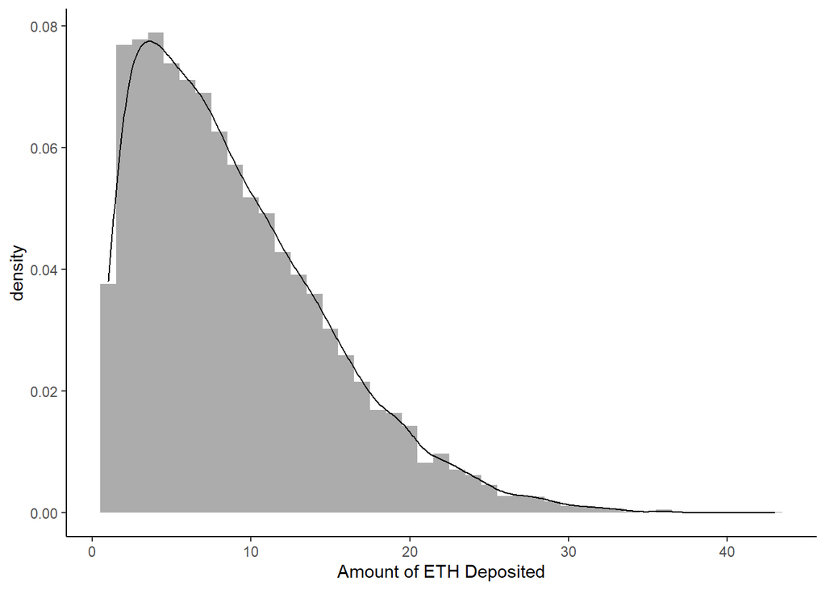

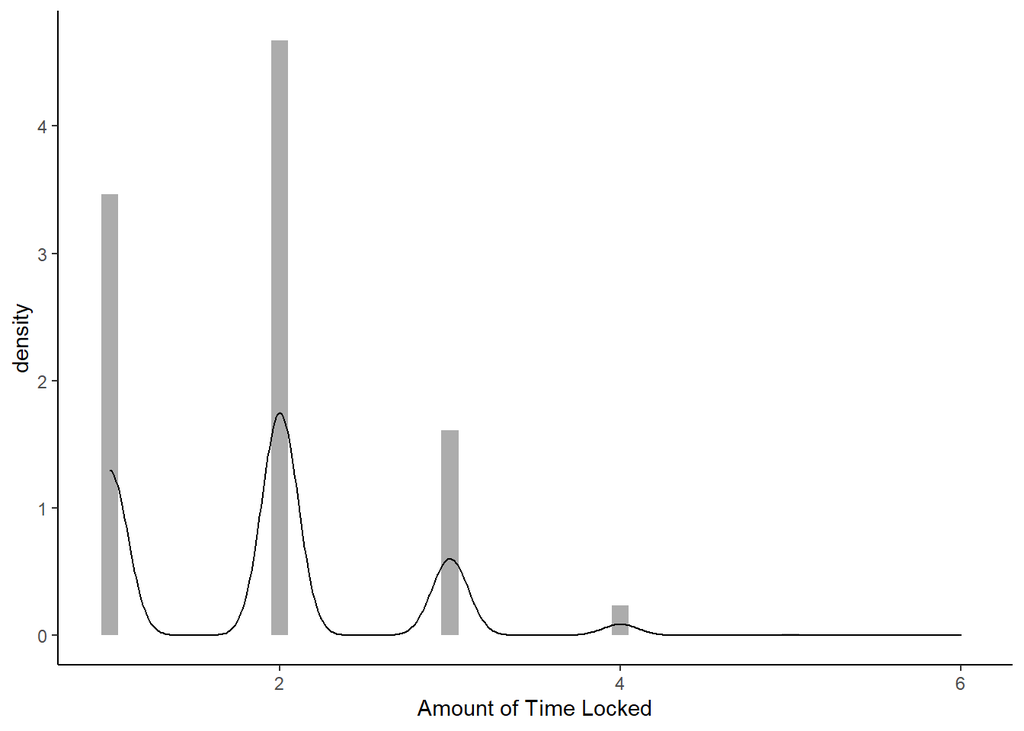

Locking ETH mints frETH as a function of `deposit` amount * `time` locked and has a similar distribution:

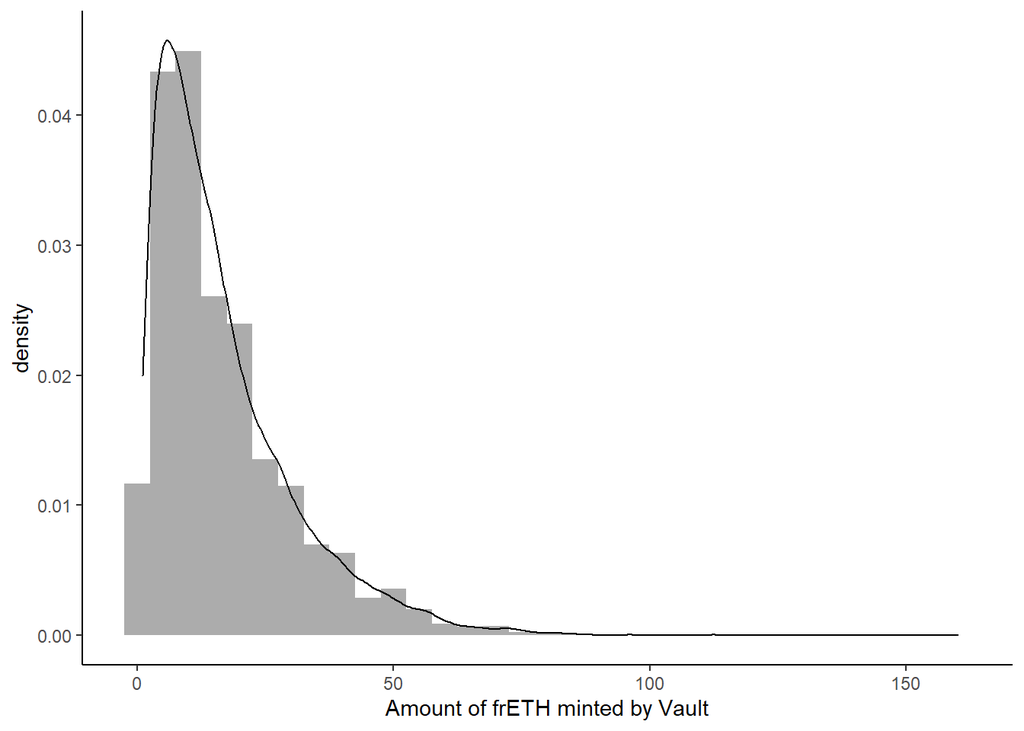

A sneak peek of the resulting vault table with cost breakdowns is provided here:

| vault_id | deposit | time | breakeven_time | mint | initial_cost | halfway_cost | threequarter_cost |
| --- | --- | --- | --- | --- | --- | --- | --- |
| KCG3BXAT80 | 27 | 3 | 2.01 | 81 | 97.2 | 89.1 | 40.5 |
| B5EOVEKPNU | 3 | 1 | 0.67 | 3 | 3.6 | 3.3 | 1.5 |
| AX5MTL2ENH | 4 | 1 | 0.67 | 4 | 4.8 | 4.4 | 2.0 |
| J73VKZVM9B | 2 | 1 | 0.67 | 2 | 2.4 | 2.2 | 1.0 |
| 8WUEHJAH6O | 1 | 3 | 2.01 | 3 | 3.6 | 3.3 | 1.5 |
| 6L5NDRLE6A | 1 | 3 | 2.01 | 3 | 3.6 | 3.3 | 1.5 |
| 07M8E1DXH9 | 9 | 1 | 0.67 | 9 | 10.8 | 9.9 | 4.5 |
| ISWCIZVI89 | 12 | 1 | 0.67 | 12 | 14.4 | 13.2 | 6.0 |
| GLI7Y4JKZM | 6 | 3 | 2.01 | 18 | 21.6 | 19.8 | 9.0 |
| SHGZ7NMXU8 | 8 | 2 | 1.34 | 16 | 19.2 | 17.6 | 8.0 |

## Patience Profiles

### Extreme Impatience

Extreme impatience is characterized by:

70% of vaults withdrawing prior to their breakeven date (“halfway”) 15% of vaults withdrawing exactly at breakeven (“breakeven”) 10% of vaults withdrawing near completion (“mostly”) 5% of vaults withdrawing upon completion

The resulting metrics are provided here:

| ETH Deposited | frETH Minted | frETH Penalties Paid | frETH Penalties Burned | frETH Supply | frETH supply per ETH deposited | frETH supply per frETH Minted | ETH Fees Paid |
| --- | --- | --- | --- | --- | --- | --- | --- |
| 89980 | 168203 | 11866.8 | 5933.4 | 162269.6 | 1.803396 | 0.9647248 | 427.21 |